# 20220615_Sageman_missing_ERGMs

2022-06-28

## Loading in stuff

```r
# load packages
library('igraph')
library('sna')
library('ergm')
library('network')
library('here')
```

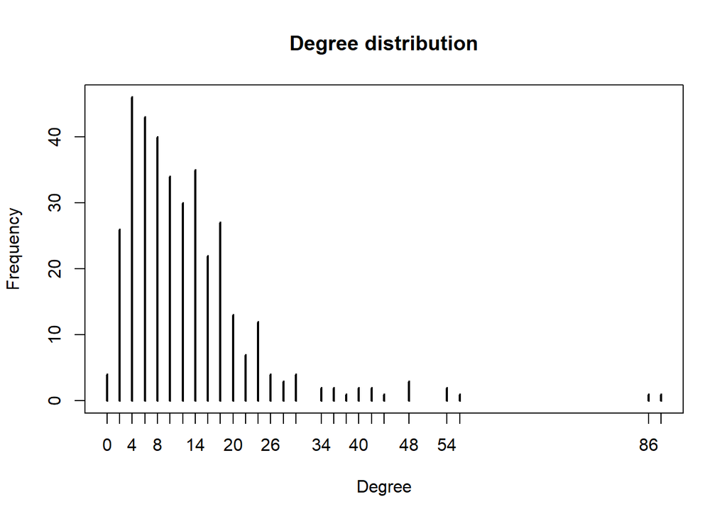

```r
# Read adjacency matrix
SagemanAdjacencyMatrix <- read.csv(here("../Data/SagemanNoordin/sagemanAdjacency.csv"), header=FALSE)

# there are a lot of attributes (you may get a list of what they are from me)
ADJ <- as.matrix(SagemanAdjacencyMatrix)
SageAttributes <- read.csv(here('../Data/SagemanNoordin/sageAttributes.csv'))

# To just get a list of the names of the vertices:
SageNames <- read.csv(here('../Data/SagemanNoordin/vertices.csv'),stringsAsFactors=FALSE)

# degree dist
plot(table(rowSums(ADJ) + colSums(ADJ)), ylab = "Frequency", xlab = "Degree", main = "Degree distribution")
```

## Generating missing data

```r
## Before building the ERGM, we need to impute some attribute data.

###### FUNCTION FOR QUICK AND DIRTY IMPUTATION of attributes
impute.miss <- function(dat.vec, use.range, use.prob=NA){

  ## impute.miss(dat.vec, use.range, use.prob = NA) takes a data vector and imputes the
  ## missing values with the specified range of values. Imputation can be probabilistically
  ## weighted if required else impued values are uniformly distributed.
  ##
  ## Input:
  ##  - dat.vec: data vector containing missing (NA) values.
  ##
  ##  - use.range: range of values to be used for imputation
  ##
  ##  - use.prob: a specified probability distribution for imputed values. Default is set
  ##              to NA, which is equivalent to a uniform distribution.
  ##
  ## Output:
  ##  - The data vector that has been imputed with the pre-specified values.

  ### branch for no specified probability distribution for the imputed values
  if (any(is.na(use.prob))){
    dat.vec[is.na( dat.vec ) ] <- sample(use.range,size=sum(is.na(dat.vec)),replace=TRUE)
  }

  ### branch for a specified probability distribution for the imputed values
  if (any(!is.na(use.prob))){
    dat.vec[is.na( dat.vec ) ] <- sample(use.range,size=sum(is.na(dat.vec)),replace=TRUE,prob=use.prob)
  }

 return(dat.vec)
}

# as a proxy for 'seniority'
SageAttributes$Year.joined.the.jihad <- impute.miss(SageAttributes$Year.joined.the.jihad,c(1992:2000))

# now we have the attribute data ready
```

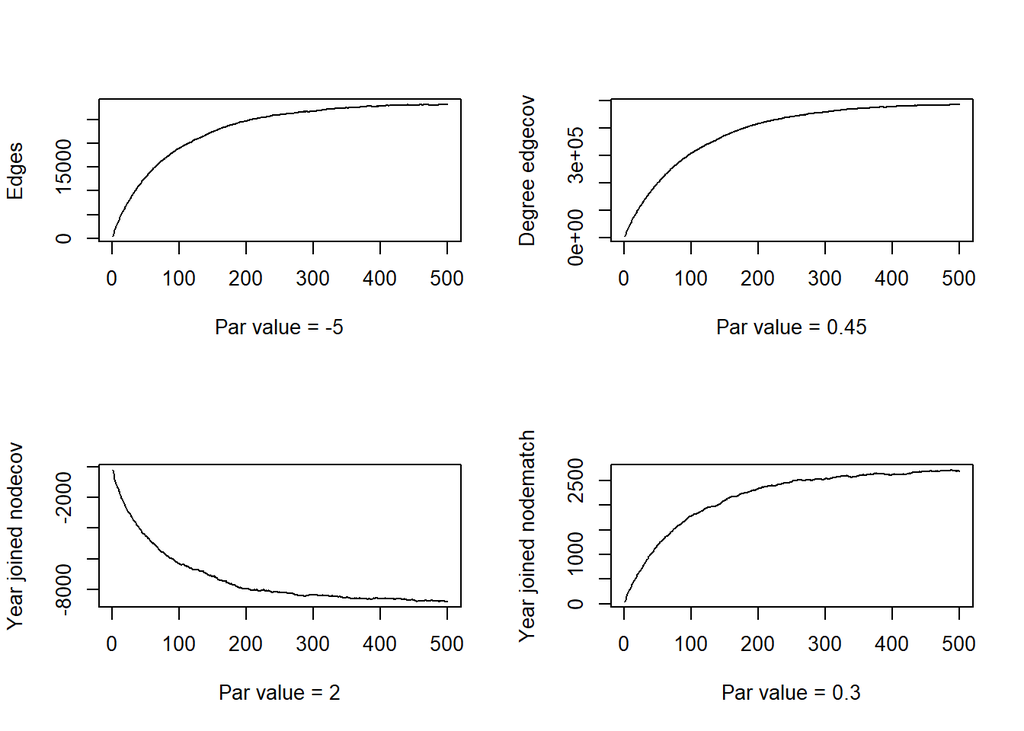

```r
# starting point for missMatrix D
missMatrix = matrix(0, nrow = nrow(ADJ), ncol = ncol(ADJ))

## edge covariate for the sum of degrees
# a cute piece of vectorised code to give each tie variable a weight based on the sender and receiver
sentTies = matrix(rep(rowSums(ADJ), nrow(ADJ)), nrow = nrow(ADJ), ncol = ncol(ADJ))
receivedTies = matrix(rep(colSums(ADJ), ncol(ADJ)), nrow = nrow(ADJ), ncol = ncol(ADJ), byrow = T)

# sum them up for an edge covariate weighed by degree
degreeCov = sentTies + receivedTies

# diag is 0 because adjmat
diag(degreeCov) = 0

#
# # another way to do it (for a check)
#
# # an empty matrix
# degreeCov2 = missMatrix
#
# # nested loooops
# for(rowInd in 1:nrow(ADJ)){
#   for(colInd in 1:ncol(ADJ)){
#
#     degreeCov2[rowInd, colInd] = rowSums(ADJ)[rowInd] + colSums(ADJ)[colInd]
#
#   }
# }
#
# # a check
# sum(degreeCov != degreeCov2)

## build-a-ergm time
# put covariates in a network object
missNet = as.network(missMatrix, directed = FALSE)

missNet %v% 'year.joined' = (SageAttributes$Year.joined.the.jihad-1996)/6  # centring because scale


mod1 = missNet ~ edges +
  edgecov(degreeCov) +
  nodecov('year.joined') +
  nodematch('year.joined')

### simulating networks with arbitrary parameters
# choosing arbitrary parameters
chosenCoef = c(-5,      # edges
               0.45,    # edgecov(degreeCov)
               2,       # nodecov('year.joined')
               0.3)     # nodematch{'year.joined'}

# generate simulated networks
simMissNetStats <- simulate(mod1 ,
                       coef = chosenCoef,# I think these parameters should yield non-degenerate models
                       nsim = 500 ,# how many samples to pick up
                       control=control.simulate.formula(MCMC.burnin=1024,MCMC.interval=1024),#for estimate it is 'control'
                       output='stats')

# trace plots to see how the prameter values are doing
par(mfrow = c(2,2))
plot(ts(simMissNetStats[,"edges"]), ylab = "Edges", xlab = paste("Par value =", chosenCoef[1]))
plot(ts(simMissNetStats[,"edgecov.degreeCov"]), ylab = "Degree edgecov", xlab = paste("Par value =", chosenCoef[2]))
plot(ts(simMissNetStats[,"nodecov.year.joined"]), ylab = "Year joined nodecov", xlab = paste("Par value =", chosenCoef[3]))
plot(ts(simMissNetStats[,"nodematch.year.joined"]), ylab = "Year joined nodematch", xlab = paste("Par value =", chosenCoef[4]))
```

```r
# # give it a shot
# simMissNet <- simulate(mod1 ,
#                        coef = chosenCoef,# I think these parameters should yield non-degenerate models
#                        nsim = 200 ,# how many samples to pick up
#                        control=control.simulate.formula(MCMC.burnin=1024,MCMC.interval=1024))
#
# # arbitrarily pick some of the networks with ~33% density (which is ~22k edges)
#
# testMissNets = list()
#
# # grab 10 simulated nets
# for(i in 1:10){
#   testMissNets[[i]] = simMissNet[[i + 141]]
# }
#
# # temporarily make a save so I don't have to re-simulate
# save(testMissNets, file = here("Output", "20220616_SagemanERGMs_testMissNets.RData"))

# just for kicks, try estimating the same ergm to see if the parameter values match
# eeeeehh... estimates are off, but around the same ballpark.
```

**What exactly is the code in this section doing?**

The idea here is to conveniently use the fact that the missing data indicator matrix $\mathbf{D}$ takes the same form as the adjacency matrix $\mathbf{X}$. So what we can try to do is to use an ERGM with an ‘arbitrary’ set of parameters following some pre-specified model to simulate a manifestation of some missing data model (of which the ERGM is mimicking).

Generally speaking,

$$\mathbf{D} \sim
ERGM(\theta).$$

And in this particular case,

$$\Pr(\mathbf{D}_{ij} = d_{ij} |
\mathbf{W} = w) = \frac{1}{\kappa(\theta)} \exp{\theta^{T}z(d) +
\theta_{a}^{T}z_{a}(d,w)},$$

where $\mathbf{W}$ represents a matrix of actor attributes, $\theta$ represent the model parameters for dyadically-independent model terms $z(d)$. $\theta_a$ and $z_a(d,w)$ represent the model parameters and model terms respectively for network structures involving actor attributes (e.g., node covariates account for values in $\mathbf{W}$).

For the current case, the covariates used in the ERGM are

1. edgecov(degreeCov), which is an edge covariate that weighs each tie variable for the sender and receiver’s degree,

$$\mathbf{M}_{ij} = \mathbf{X}_{i+} +
\mathbf{X}_{+j},$$

where $\mathbf{M}$ refers to the edge covariate matrix.

2. A node covariate for the year the node joined the network (i.e., as a proxy for ‘seniority’),

$$\sum_j d_{ij} {year}_i,$$

3. A nodematch covariate to weigh the probability of a tie depending nodes matching on the year they joined the network.

I (arbitrarily) set the parameter values to be positive to indicate how the three covariates have a positive relationship with a tie being formed. The absolute values are somewhat inconsequential for the moment other than for network density reasons.

## Degrading networks

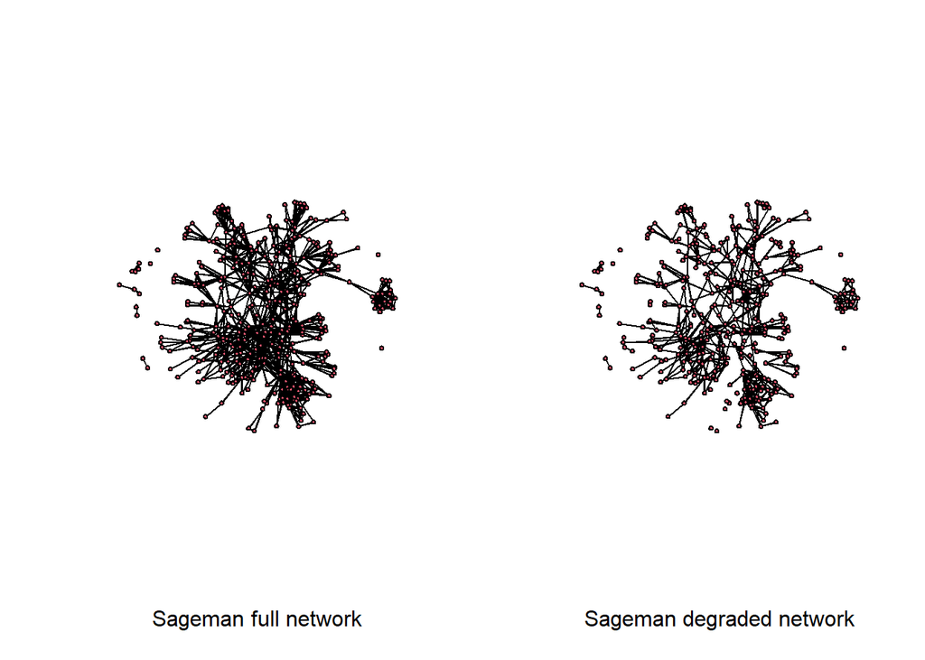

```r
### loading the list of missing networks
load(file = here("Output", "20220616_SagemanERGMs_testMissNets.RData"))


## Todd
toddNets = list()

for( i in 1:10 ){
  toddNets[[i]] = ADJ
  toddNets[[i]][as.matrix(testMissNets[[i]]) == 1] = 0
}


## Peter
peterNets = list()

for( i in 1:10 ){
  peterNets[[i]] = ADJ
  peterNets[[i]][as.matrix(testMissNets[[i]]) == 1] = NA
}

# compare a todd and full
par(mfrow = c(1,2))
coord = gplot(ADJ, gmode = "graph", xlab = "Sageman full network", )
gplot(toddNets[[1]], gmode = "graph", xlab = "Sageman degraded network", coord = coord)
```

```r
## turn them into network objects and add sageman attributes
# keep these attributes constant so I'll just use the one from Johan's script
load(here("Data", "SagemanImputedData.RData"))

toddNets = lapply(toddNets, FUN = as.network, directed = FALSE)

peterNets = lapply(peterNets, FUN = as.network, directed = FALSE)

## too lazy to think of a smarter way of doing this so,

for( i in 1:10 ){
  # put attributes in todd networks
  toddNets[[i]] %v% 'age' = alqnet %v% 'age'
  toddNets[[i]] %v% 'age.join' = alqnet %v% 'age.join'
  toddNets[[i]] %v% 'clump' = alqnet %v% 'clump'
  toddNets[[i]] %v% 'country.joined' = alqnet %v% 'country.joined'
  toddNets[[i]] %v% 'educ' = alqnet %v% 'educ'
  toddNets[[i]] %v% 'place.joined' = alqnet %v% 'place.joined'
  toddNets[[i]] %v% 'plbirth' = alqnet %v% 'plbirth'
  toddNets[[i]] %v% 'school' = alqnet %v% 'school'
  toddNets[[i]] %v% 'ses' = alqnet %v% 'ses'
  toddNets[[i]] %v% 'vertex.names' = alqnet %v% 'vertex.names'
  toddNets[[i]] %v% 'year.joined' = alqnet %v% 'year.joined'
  peterNets[[i]] %v% 'age' = alqnet %v% 'age'
  peterNets[[i]] %v% 'age.join' = alqnet %v% 'age.join'
  peterNets[[i]] %v% 'clump' = alqnet %v% 'clump'
  peterNets[[i]] %v% 'country.joined' = alqnet %v% 'country.joined'
  peterNets[[i]] %v% 'educ' = alqnet %v% 'educ'
  peterNets[[i]] %v% 'place.joined' = alqnet %v% 'place.joined'
  peterNets[[i]] %v% 'plbirth' = alqnet %v% 'plbirth'
  peterNets[[i]] %v% 'school' = alqnet %v% 'school'
  peterNets[[i]] %v% 'ses' = alqnet %v% 'ses'
  peterNets[[i]] %v% 'vertex.names' = alqnet %v% 'vertex.names'
  peterNets[[i]] %v% 'year.joined' = alqnet %v% 'year.joined'
}

# save these networks to be used for an estimation later
save(toddNets, peterNets, file = here("Output", "20220616_sagemanERGMs_todd_peter_nets.RData"))
```